# Unit 6 Case Study - Real Time Location

Rahn Lieberman, Jainy Selvakumar, Mike Sylvester, Shobana Sundaram

# [1.1] Introduction

A current area of interest in many industries is determining an internet connected device’s location. This could be a phone, a tablet or laptop, or something else with some sort of tracking chip embedded in it. By examining a devices name, and how it connects to different access points in a physical area with a known network topology, we can determine it’s location.

Some practical uses of this may be to track someones location in a store to see where they are spending the most time. One could then examine what is in that area to determine what people are most interested in buying.

For this case study, we are using some known R code to read and analyze a device location in an office. See [1] for specific information.

We diverge from the code and analysis path given to examine two different MAC addresses and how the results differ based on whether they are included or not. In addition, the location prediction model using K nearest neighbors was explored to see if a weighted mean based on signal strength would improve accuracy over a simple mean.

The first portion of the code below is setting up and cleaning the dataset. The data exploration and detail analysis begins in section 1.3.

# [1.2] Import Data and inital cleanup

First thing to do is load our data, and do some initial evaluation of it. We also clean up the data to put correct types on each column.

```r
#Create a function to remove unwanted characters
processLine = function(x) {
  tokens = strsplit(x, "[;=,]")[[1]] #This is using a regex in the split to break as [ ] = , characters
  if (length(tokens) <= 10)
      return(NULL)

  tmp = matrix(tokens[ - (1:10) ], ncol = 4, byrow = TRUE)
  cbind(matrix(tokens[c(2, 4, 6:8, 10)], nrow = nrow(tmp), ncol = 6, byrow = TRUE), tmp)
}
# Create a function that will make all the orientations line up to the closed "true" value
# that we are interested in.  i.e. 0, 45, 90, etc.
roundOrientation = function(angles) {
  refs = seq(0, by = 45, length = 9)
  q = sapply(angles, function(o) which.min(abs(o - refs)))
  c(refs[1:8], 0)[q]
}
#Create a function to read data
readData =
function(filename = 'offline.final.trace.txt',
subMacs = c("00:0f:a3:39:e1:c0", "00:0f:a3:39:dd:cd", "00:14:bf:b1:97:8a",
"00:14:bf:3b:c7:c6", "00:14:bf:b1:97:90", "00:14:bf:b1:97:8d",
"00:14:bf:b1:97:81"))
{
  txt = readLines(filename)

  #Remove the comment lines ,beginning with a #
  lines = txt[ substr(txt, 1, 1) != "#" ]

  # This line is to raise errors when warnings occur.
  options(error = recover, warn = 1)
  tmp = lapply(lines, processLine)
  # The above gives us a matrix of the values.
  # We want to combine all matrices together
  offline = as.data.frame(do.call("rbind", tmp),
  stringsAsFactors = FALSE)

  names(offline) = c("time", "scanMac",
  "posX", "posY", "posZ", "orientation",
  "mac", "signal", "channel", "type")

  # keep only signals from access points
  offline = offline[ offline$type == "3", ]

  # convert numeric values
  numVars = c("time", "posX", "posY", "orientation", "signal")
  offline[ numVars ] = lapply(offline[ numVars ], as.numeric)

  # convert time to POSIX
  offline$rawTime = offline$time
  offline$time = offline$time/1000
  class(offline$time) = c("POSIXt", "POSIXct")

  # convert orientation to angle
  offline$angle = roundOrientation(offline$orientation)

  # drop scanMac, posZ, channel, and type - no info in them
  dropVars = c("scanMac", "posZ", "channel", "type")
  offline = offline[ , !( names(offline) %in% dropVars ) ]

  # drop more unwanted access points
  offline = offline[ offline$mac %in% subMacs, ]

  return(offline)
}
```

# [1.3] Cleaning the Data and Preparing for Analysis

```r
  offline = readData()
dim(offline)
```

```
[1] 914951      8
```

## [1.3.1] Orientation of the devices

Each device should be orientated in one of 8 directions. These should be listed in degrees, and each direction is 45 degrees apart.

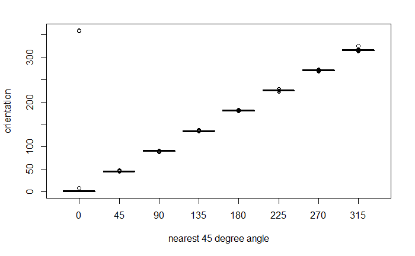

```r
with(offline, boxplot(orientation ~ angle,
  xlab = "nearest 45 degree angle",
  ylab = "orientation"))
```

## [1.3.2] Exploring MAC address

The original dataset contained 12 MAC addresses and 8 channels. In initial analysis, We observed that the MAC addresses have a one to one correspondence with channels. Therefore, we removed the redundant channel data in the readData function above. In addition, we were only expecting 6 access points. The additional MAC addresses had a low number of observations. Therefore, the code below will keep only the MAC addresses with top 7 readings. However, since we have already prepped the data by filtering to the MAC addresses of interest in the readData function above, running the code below will have no additional clean up impact.

```r
c(length(unique(offline$mac)), length(unique(offline$signal)))
```

```
[1]  7 73
```

```r
table(offline$mac)
```

```
00:0f:a3:39:dd:cd 00:0f:a3:39:e1:c0 00:14:bf:3b:c7:c6 00:14:bf:b1:97:81 00:14:bf:b1:97:8a 00:14:bf:b1:97:8d 00:14:bf:b1:97:90
           145619            145862            126529            120339            132962            121325            122315
```

```r
subMacs = names(sort(table(offline$mac), decreasing = TRUE))[1:7]
offline = offline[ offline$mac %in% subMacs, ]
dim(offline)
```

```
[1] 914951      8
```

## [1.3.3]Exploring the Position of the Hand-Held Device

```r
locDF = with(offline,
    by(offline, list(posX, posY), function(x) x))
    length(locDF)
```

```
[1] 476
```

```r
sum(sapply(locDF, is.null))
```

```
[1] 310
```

```r
locDF = locDF[ !sapply(locDF, is.null) ]
#How many different locations do we have data for?
length(locDF)
```

```
[1] 166
```

```r
locCounts = sapply(locDF, nrow)
locCounts = sapply(locDF,
function(df)
c(df[1, c("posX", "posY")], count = nrow(df)))
class(locCounts)
```

```
[1] "matrix"
```

```r
dim(locCounts)
```

```
[1]   3 166
```

```r
#How many observations do we have for each location?
locCounts[ , 1:8]
```

```
      [,1] [,2] [,3] [,4] [,5] [,6] [,7] [,8]
posX  0    1    2    0    1    2    0    1
posY  0    0    0    1    1    1    2    2
count 5505 5505 5506 5524 5543 5558 5503 5564
```

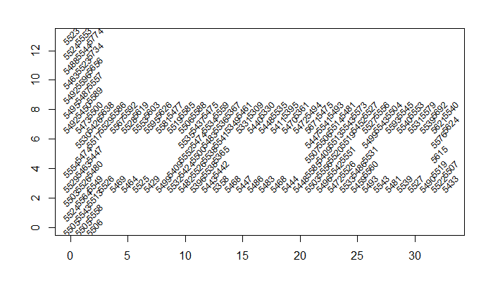

```r
#Create a plot of the number of observations for each location
locCounts = t(locCounts)
plot(locCounts, type = "n", xlab = "", ylab = "")
text(locCounts, labels = locCounts[,3], cex = .8, srt = 45)
```

```r
# Find global variables that are needed if we run this in a new R session
library(codetools)
findGlobals(readData, merge=FALSE)$variables
```

```
[1] "as.numeric"  "processLine" "recover"
```

# [1.4] Signal Strength Analysis

## [1.4.1] Distribution of Signal Strength

Factor containing all unique combinations of (x,y) pairs at 166 locations. And creating data frames for every combination of (x, y) angle and access point

```r
offline$posXY = paste(offline$posX, offline$posY, sep = "-")
byLocAngleAP = with(offline,
                    by(offline, list(posXY, angle, mac),
                       function(x) x))
#Function to summarize signal data by AP, location and angle
signalSummary =
  lapply(byLocAngleAP,
         function(oneLoc) {
           ans = oneLoc[1, ]
           ans$medSignal = median(oneLoc$signal)
           ans$avgSignal = mean(oneLoc$signal)
           ans$num = length(oneLoc$signal)
           ans$sdSignal = sd(oneLoc$signal)
           ans$iqrSignal = IQR(oneLoc$signal)
           ans
         })
## Create a new data frame of the summary statistics
offlineSummary = do.call("rbind", signalSummary)
```

# [1.4.2] Examine the Relationship between Signal and Distance

```r
#Create a function to draw the heat map by passing parameters
surfaceSS = function(data, mac, angle = 45) {
  require(fields)
  oneAPAngle = data[ data$mac == mac & data$angle == angle, ]
  smoothSS = Tps(oneAPAngle[, c("posX","posY")],
                 oneAPAngle$avgSignal)
  vizSmooth = predictSurface(smoothSS)
  plot.surface(vizSmooth, type = "C",
               xlab = "", ylab = "", xaxt = "n", yaxt = "n")
  points(oneAPAngle$posX, oneAPAngle$posY, pch=19, cex = 0.5)
}
```

Run the heatmap for both access points of interest

```r
parCur = par(mfrow = c(2,2), mar = rep(1, 4))
mapply(surfaceSS, mac = subMacs[ rep(c(5, 1), each = 2) ],
       angle = rep(c(0, 135), 2),
       data = list(data = offlineSummary))
```

[output not shown]

```
[1] 6400    2
[1] 6400    2
[1] 6400    2
[1] 6400    2
$`00:14:bf:b1:97:90`
NULL

$`00:14:bf:b1:97:90`
NULL

$`00:0f:a3:39:e1:c0`
NULL

$`00:0f:a3:39:e1:c0`
NULL
```

[figure not shown]

```r
par(parCur)
```

```r
#
# #MAC address of 00:0f:a3:39:e1:c0
# offlineSummary = subset(offlineSummary, mac = subMacs[1])
#
# #create a matrix for the access points on the floor plan
# AP = matrix( c( 7.5, 6.3, 2.5, -.8, 12.8, -2.8,
#                 1, 14, 33.5, 9.3,  33.5, 2.8),
#             ncol = 2, byrow = TRUE,
#             dimnames = list(subMacs[ -2 ], c("x", "y") ))
#
# AP
#
# #MAC address of 00:0f:a3:39:dd:cd
# offlineSummary = subset(offlineSummary, mac = subMacs[2])
#
# #create a matrix for the access points on the floor plan
# AP = matrix( c( 7.5, 6.3, 2.5, -.8, 12.8, -2.8,
#                 1, 14, 33.5, 9.3,  33.5, 2.8),
#             ncol = 2, byrow = TRUE,
#             dimnames = list(subMacs[ -1 ], c("x", "y") ))
#
# AP
#MAC address of 00:0f:a3:39:dd:cd is dropped
offlineSummary = subset(offlineSummary, mac != subMacs[2])
#create a matrix for the access points on the floor plan
AP = matrix( c( 7.5, 6.3, 2.5, -.8, 12.8, -2.8,
                1, 14, 33.5, 9.3,  33.5, 2.8),
            ncol = 2, byrow = TRUE,
            dimnames = list(subMacs[ -2 ], c("x", "y") ))
AP
```

```
                     x    y
00:0f:a3:39:e1:c0  7.5  6.3
00:14:bf:b1:97:8a  2.5 -0.8
00:14:bf:3b:c7:c6 12.8 -2.8
00:14:bf:b1:97:90  1.0 14.0
00:14:bf:b1:97:8d 33.5  9.3
00:14:bf:b1:97:81 33.5  2.8
```

Exploring the relationship between signal strenth and distance from access point

```r
#calculate the distance from device to access point
diffs = offlineSummary[ , c("posX", "posY")] -
          AP[ offlineSummary$mac, ]
#Calculate Euclidean distance betweeen device and access point
offlineSummary$dist = sqrt(diffs[ , 1]^2 + diffs[ , 2]^2)
# #draw scatterplots of each access point and orientation
# xyplot(signal ~ dist | factor(mac) + factor(angle),
#        data = offlineSummary, pch = 19, cex = 0.3,
#        xlab ="distance")
#
# pdf(file="Geo_ScatterSignalDist.pdf", width = 7, height = 10)
# oldPar = par(mar = c(3.1, 3.1, 1, 1))
# library(lattice)
# xyplot(signal ~ dist | factor(mac) + factor(angle),
#        data = offlineSummary, pch = 19, cex = 0.3,
#        xlab ="distance")
# par(oldPar)
# dev.off()
```

# [1.5] K Nearest Neighbor Method to Predict Location

## [1.5.1]Preparing the Test Data

```r
#Use the readData function to create a dataframe using the test data
macs = unique(offlineSummary$mac)
online = readData("online.final.trace.txt", subMacs = macs)
#Create data frames for each unique location identifier for every combination of (x, y) angle and access point
online$posXY = paste(online$posX, online$posY, sep = "-")
#How many unique test locations do we have?
length(unique(online$posXY))
```

```
[1] 60
```

```r
#How many observations do we have for each location?
tabonlineXYA = table(online$posXY, online$angle)
tabonlineXYA[1:6, ]
```

```
               0  45  90 135 180 225 270 315
  0-0.05       0   0   0 593   0   0   0   0
  0.15-9.42    0   0 606   0   0   0   0   0
  0.31-11.09   0   0   0   0   0 573   0   0
  0.47-8.2   590   0   0   0   0   0   0   0
  0.78-10.94 586   0   0   0   0   0   0   0
  0.93-11.69   0   0   0   0 583   0   0   0
```

```r
#create a dataframe of the signal strengths with each access point in its own column
keepVars = c("posXY", "posX","posY", "orientation", "angle")
byLoc = with(online,
             by(online, list(posXY),
                function(x) {
                  ans = x[1, keepVars]
                  avgSS = tapply(x$signal, x$mac, mean)
                  y = matrix(avgSS, nrow = 1, ncol = 6,
                        dimnames = list(ans$posXY, names(avgSS)))
                  cbind(ans, y)
                }))
onlineSummary = do.call("rbind", byLoc)
dim(onlineSummary)
```

```
[1] 60 11
```

```r
#Find the angles that are neighboring angles that can help filter the training data when calculating the test data
#m = number of angles and angleNewObs = angle of the new observation
m = 3; angleNewObs = 230
refs = seq(0, by = 45, length  = 8)
nearestAngle = roundOrientation(angleNewObs)
if (m %% 2 == 1) {
  angles = seq(-45 * (m - 1) /2, 45 * (m - 1) /2, length = m)
} else {
  m = m + 1
  angles = seq(-45 * (m - 1) /2, 45 * (m - 1) /2, length = m)
  if (sign(angleNewObs - nearestAngle) > -1)
    angles = angles[ -1 ]
  else
    angles = angles[ -m ]
}
#Remap the angles to be consistent to the values in refs
angles = angles + nearestAngle
angles[angles < 0] = angles[ angles < 0 ] + 360
angles[angles > 360] = angles[ angles > 360 ] - 360
#Selected the angles of interest from the training dataset
offlineSubset =
  offlineSummary[ offlineSummary$angle %in% angles, ]
#Create a function to create a dataframe of the filtered data similar to the summary table
reshapeSS = function(data, varSignal = "signal",
                     keepVars = c("posXY", "posX","posY")) {
  byLocation =
    with(data, by(data, list(posXY),
                  function(x) {
                    ans = x[1, keepVars]
                    avgSS = tapply(x[ , varSignal ], x$mac, mean)
                    y = matrix(avgSS, nrow = 1, ncol = 6,
                               dimnames = list(ans$posXY,
                                               names(avgSS)))
                    cbind(ans, y)
                  }))
  newDataSS = do.call("rbind", byLocation)
  return(newDataSS)
}
trainSS = reshapeSS(offlineSubset, varSignal = "avgSignal")
#Create a function to select the angles and reshape the dataframe given the parameters
selectTrain = function(angleNewObs, signals = NULL, m = 1){
  # m is the number of angles to keep between 1 and 5
  refs = seq(0, by = 45, length  = 8)
  nearestAngle = roundOrientation(angleNewObs)
  if (m %% 2 == 1)
    angles = seq(-45 * (m - 1) /2, 45 * (m - 1) /2, length = m)
  else {
    m = m + 1
    angles = seq(-45 * (m - 1) /2, 45 * (m - 1) /2, length = m)
    if (sign(angleNewObs - nearestAngle) > -1)
      angles = angles[ -1 ]
    else
      angles = angles[ -m ]
  }
  angles = angles + nearestAngle
  angles[angles < 0] = angles[ angles < 0 ] + 360
  angles[angles > 360] = angles[ angles > 360 ] - 360
  angles = sort(angles)
  offlineSubset = signals[ signals$angle %in% angles, ]
  reshapeSS(offlineSubset, varSignal = "avgSignal")
}
```

```r
#test the function using m = 3 and angle of 130
# train130 = selectTrain(130, offlineSummary, m = 3)
#
# head(train130)
#
# length(train130[[1]])
```

## [1.5.2] Finding the Nearest Neighbors

```r
#Create a function to find the nearest neigbor of a new point based on the training data (in terms of signal strngths)
findNN = function(newSignal, trainSubset) {
  diffs = apply(trainSubset[ , 4:9], 1,
                function(x) x - newSignal)
  dists = apply(diffs, 2, function(x) sqrt(sum(x^2)) )
  closest = order(dists)
  return(trainSubset[closest, 1:3 ])
}
```

### [1.5.2.1] Estimate Using a Simple Average

```r
#Create a function to predict the location of the new point based on the nearest neighbors identified by findNN
predXY = function(newSignals, newAngles, trainData,
                  numAngles = 1, k = 3){

  closeXY = list(length = nrow(newSignals))

  for (i in 1:nrow(newSignals)) {
    trainSS = selectTrain(newAngles[i], trainData, m = numAngles)
    closeXY[[i]] =
      findNN(newSignal = as.numeric(newSignals[i, ]), trainSS)
  }
  estXY = lapply(closeXY,
                 function(x) sapply(x[ , 2:3],
                                    function(x) mean(x[1:k])))
  estXY = do.call("rbind", estXY)
  return(estXY)
}
```

### [1.5.2.2] Estimate Using a Weighted Average

```r
# Weighted average function for k = 1
predXY_w = function(newSignals, newAngles, trainData,
                  numAngles = 1, k = 1){

  closeXY = list(length = nrow(newSignals))

  for (i in 1:nrow(newSignals)) {
    trainSS = selectTrain(newAngles[i], trainData, m = numAngles)
    closeXY[[i]] =
      findNN(newSignal = as.numeric(newSignals[i, ]), trainSS)
  }

  nz=.001
  estXY = lapply(closeXY,
                 function(x) sapply(x[ , 2:3], function(x) weighted.mean(x[1:k], c(1/(sum(x[1])+nz)))))

  estXY = do.call("rbind", estXY)
  return(estXY)
}
# Weighted average function for k = 3
predXY3_w = function(newSignals, newAngles, trainData,
                  numAngles = 1, k = 3){

  closeXY = list(length = nrow(newSignals))

  for (i in 1:nrow(newSignals)) {
    trainSS = selectTrain(newAngles[i], trainData, m = numAngles)
    closeXY[[i]] =
      findNN(newSignal = as.numeric(newSignals[i, ]), trainSS)
  }

  nz=.001
  estXY = lapply(closeXY,
                 function(x) sapply(x[ , 2:3], function(x) weighted.mean(x[1:k], c(1/(sum(x[1])+nz), 1/(sum(x[2])+nz),1/(sum(x[3])+nz)))))

  estXY = do.call("rbind", estXY)
  return(estXY)
}
# Weighted average function for k = 5
predXY5_w = function(newSignals, newAngles, trainData,
                  numAngles = 1, k = 5){

  closeXY = list(length = nrow(newSignals))

  for (i in 1:nrow(newSignals)) {
    trainSS = selectTrain(newAngles[i], trainData, m = numAngles)
    closeXY[[i]] =
      findNN(newSignal = as.numeric(newSignals[i, ]), trainSS)
  }

  nz=.001
  estXY = lapply(closeXY,
                 function(x) sapply(x[ , 2:3], function(x) weighted.mean(x[1:k], c(1/(sum(x[1])+nz), 1/(sum(x[2])+nz),1/(sum(x[3])+nz),1/(sum(x[4])+nz),1/(sum(x[5])+nz)  ))))

  estXY = do.call("rbind", estXY)
  return(estXY)
}
```

## [1.5.3] K = 1 and K = 3

```r
#Predict using 3 nearest neighbors and 3 orientations
estXYk3 = predXY(newSignals = onlineSummary[ , 6:11],
                 newAngles = onlineSummary[ , 4],
                 offlineSummary, numAngles = 3, k = 3)
#Predict using k = 3 and weighted average
estXYk3w = predXY3_w(newSignals = onlineSummary[ , 6:11],
                 newAngles = onlineSummary[ , 4],
                 offlineSummary, numAngles = 3, k = 3)
#Predict using 1 nearest neighbors and 3 orientations
estXYk1 = predXY(newSignals = onlineSummary[ , 6:11],
                 newAngles = onlineSummary[ , 4],
                 offlineSummary, numAngles = 3, k = 1)
#Predict using k = 1 and weighted average
estXYk1w = predXY_w(newSignals = onlineSummary[ , 6:11],
                 newAngles = onlineSummary[ , 4],
                 offlineSummary, numAngles = 3, k = 1)
```

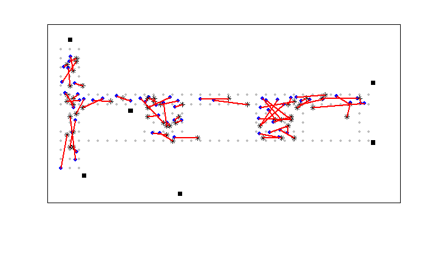

```r
floorErrorMap = function(estXY, actualXY, trainPoints = NULL, AP = NULL){

    plot(0, 0, xlim = c(0, 35), ylim = c(-3, 15), type = "n",
         xlab = "", ylab = "", axes = FALSE)
    box()
    if ( !is.null(AP) ) points(AP, pch = 15)
    if ( !is.null(trainPoints) )
      points(trainPoints, pch = 19, col="grey", cex = 0.6)

    points(x = actualXY[, 1], y = actualXY[, 2],
           pch = 19, col = "blue", cex = 0.8 )
    points(x = estXY[, 1], y = estXY[, 2],
           pch = 8, cex = 0.8 )
    segments(x0 = estXY[, 1], y0 = estXY[, 2],
             x1 = actualXY[, 1], y1 = actualXY[ , 2],
             lwd = 2, col = "red")
}
trainPoints = offlineSummary[ offlineSummary$angle == 0 &
                              offlineSummary$mac == "00:0f:a3:39:e1:c0" ,
                        c("posX", "posY")]
floorErrorMap(estXYk3, onlineSummary[ , c("posX","posY")],
              trainPoints = trainPoints, AP = AP)
```

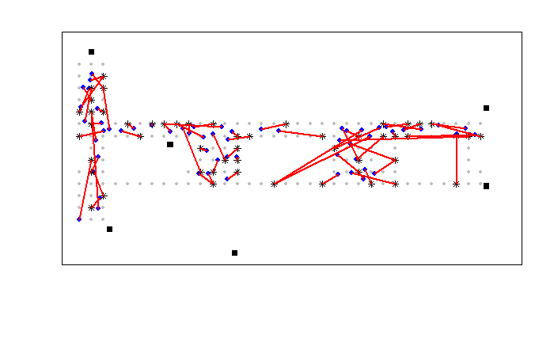

```r
floorErrorMap(estXYk1, onlineSummary[ , c("posX","posY")],
              trainPoints = trainPoints, AP = AP)
```

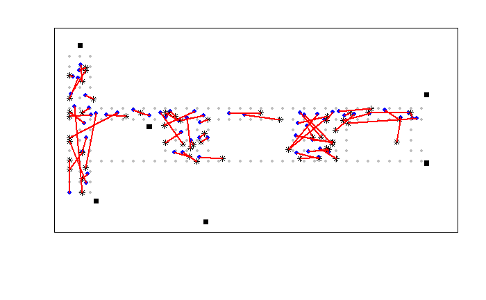

```r
floorErrorMap(estXYk3w, onlineSummary[ , c("posX","posY")],
              trainPoints = trainPoints, AP = AP)
```

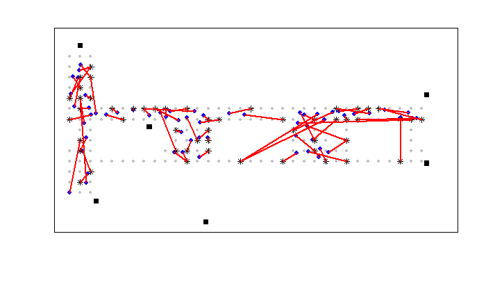

```r
floorErrorMap(estXYk1w, onlineSummary[ , c("posX","posY")],
              trainPoints = trainPoints, AP = AP)
```

```r
#Create a function to calculate the sum of squared errors
calcError =
function(estXY, actualXY)
   sum( rowSums( (estXY - actualXY)^2) )
actualXY = onlineSummary[ , c("posX", "posY")]
sapply(list(estXYk1, estXYk3, estXYk1w, estXYk3w), calcError, actualXY)
```

```
[1] 659.4003 306.7025 659.4003 445.4785
```